# Pollination

Nedan föjer en sammanfattning om vad pollination är och en fördjupning om hur det fungerar för körsbärsträd.  
Många *sötkörsbär* kan inte befruktas av individer från samma sort utan käver pollen från en annan sort för att bära frukt. För att detta skall vara möjligt måste de båda sorterna vara genetiskt kompatibla. Dessutom behöver deras blomningstid överlappa.

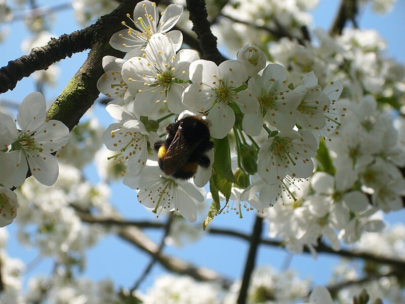

Humla på körsbärsblomma

# Introduktion

Pollination är överföring av pollenkorn från ståndarna på en blomma till pistillen på en annan. Det ger befruktning som gör att ett frö kan bildas som sedan blir en frukt.

Pollination kan ske genom att pollenkornen tas med av vinden, insekter eller andra djur. Pollinerande bin kan flyga upp till 3-4 km, men tumregeln är att träd för korspollinering bör vara inom 18 m för att det verkligen skall vara effektivt.

Hos vissa arter kan individerna befrukta sig själva, vissa kräver att pollen kommer från en annan individ och vissa kräver att pollen kommer från en annan sort.

Vardagligt brukar man med “korspollination” mena att en viss sort av körsbär (tex *Prunus avium* ‘Merton Glory’) måste pollineras av en annan sort (tex *Prunus avium* ‘Allmän gulröd bigarrå’) för att bära frukt. Dessa sorter kallas ibland “självsterila”. Se sidan om terminologi för detaljer.

En sort som *kan* pollineras av samma sort brukar kallas “självfertil” (tex *Prunus avium* ‘Stella’). De flesta surkörsbär är självfertila. Skörd och kvalitet brukar dock bli bättre även för dessa sorter om de pollineras av andra sorter (ca 10-15% mer frukt).

## Grundläggande begrepp

Bilden nedan visar namnen på blommans olika delar.

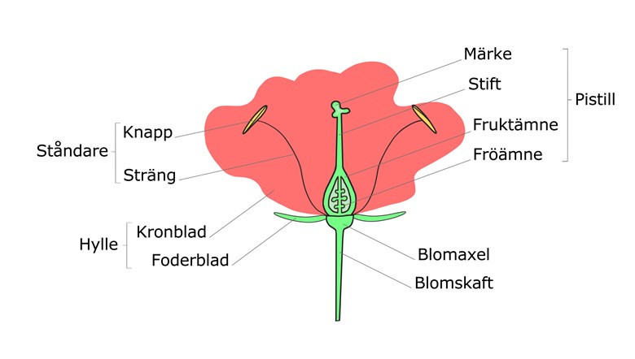

Blommans delar

# Pollination, hur funkar det

## Pollinationssekvensen

1. Pollenkornet landar på pistillens *märke*.
2. Pollenkornet växer ut en *pollenslang* som tränger ner genom pistillens *stift* ner till *fruktämnet*.
3. Pollenkornet innehåller två hanliga könsceller som vandrar ner till fruktämnet där de sammansmälter med två kvinnliga könsceller (sk “dubbelbefruktning”). En av dessa (ägget) utvecklas till ett fröembryo och den andra (centralcellen) till omgivande näringsvävnad.

Fruktämnet växer sedan till och bildar frukten.

# Genetisk kompatibilitet

Körsbär har i sina kromosomer två (hos surkörsbär fyra) varianter av ett visst genetiskt område (*locus*). En sådan variant benämns med bokstaven S och en siffra, tsex “S1”, så en körsbärssort kan vara tex “S2S6”. Då kommer den ha S2S6 i sina pistiller och det pollen den skickar iväg kommer att vara antingen S2 eller S6. En körsbärssort är “immun” mot pollen som innehåller någon av dess egna “bokstäver”. Så ett S2S6-körsbär är immunt mot pollen som innehåller S2 eller S6. Eftersom de flesta sorter har S1 till S6 blir det ganska vanligt att de är helt- eller delvis inkompatibla. Detta system kallas “Gametofytisk Själv-Inkompatibilitet” (GSI) och förekommer hos flera växtarter. Det beskrivs mer i detalj nedan.

## Genetik, några begrepp

Kromosomer: Strukturer i cellkärnan som innehåller gener.

Locus: Ett område på en kromosom där generna för en viss egenskap finns.

Alleler: Gener som finns i samma locus i ett kromosompar.

Diploid: Organism som har ett *par* av varje kromosom i cellkärnan.

Haploid: Celler med endast en uppsättning kromosomer (könsceller från diploida organismer).

Polyploidi: Förekomst av mer än ett kromosompar hos en organism. - Triploid: Tre uppsättningar. - Tetraploid: Fyra uppsättningar.

## Varför är många sorter genetiskt inkompatibla?

Huruvida pollen från en viss sort är kompatibelt med mottagaren bestäms av ett område på kromosomen som betecknas med “S”. Varianter (*alleler*) av S betecknas med olika nummer, S1, S2, S3 osv. Vanligast är S1-S6.

Pollenkornet (som innehåller två haploida celler) för endast med sig en S-allel (tex S2) och pistillen har två (tex S1S6). Pollenkorn vars S-variant är *samma* som *någon* av pistillens S-varianter kan *inte* ta sig ner genom stiftet för att befrukta mottagaren, då pollenslangens utväxt hämas.

Undantaget är S4**’**-allelen (notera apostrofen) som medför *självfertilitet*. Ett pollenkorn med S4**’** kan befrukta alla mottagare (inklusive de med S4**’**). Körsbär med S4**’** kan således betraktas som universella givare.

De enstaka själv-**in**fertila sorter som har S4**’** ej kan befruktas av S4 (utan apostrof).

Enstaka universella givare saknar också S4**’**.

Surkörsbär (tetraploida organismer) har könsceller som är diploida, varför pollenkornet innehåller två olika S-alleler och pistillen fyra. Hos dessa finns flera olika mutationer i S-allerna som kan ge självfertilitet

## Principskiss kompatibilitet

```
flowchart LR
  A[Givare S1S2] --> B1(Pollen S1)
  A --> B2(Pollen S2)
  B1 --> C{Finns S1 hos <br /> mottagaren?}
  C --> D[JA]
  C --> E[Nej]
  B2 --> F{Finns S2 hos <br /> mottagaren?}
  F --> D
  F --> E
  D --> G[STOPP!]
  E --> H[Befruktning möjlig]
```

## Exempel på kompatibilitet för en mottagare med S1S2

**Exempel A** (helt _icke_kompatibel givare)

Givaren har S1S2 och producerar därför två sorters pollenkorn som har S1 respektive S2. Mottagaren har likadana S-alleler (S1S2). Båda pollensorterna är därför _icke_kompatibla.

Det innebär att givaren är självsteril (eftersom den också har S1S2 i sin pistill) och hör till samma “inkompatibilitetsgrupp” som mottagaren.

**Exempel B** (delvis kompatibel givare)

Givaren har S1S3 och dess pollenkorn således S1 respektive S3. En av pollensorterna (S1) är därför _icke_kompatibel och den andra pollensorten (S3) är kompatibel.

**Exempel C** (helt kompatibel givare)

Givaren har S3S4 och dess pollenkorn således S3 respektive S4. Båda pollensorterna är därför kompatibla med mottagaren (S1S2).

```
flowchart LR
  A[A. Givare S1S2] --> S1(Pollen S1)
  B[B. Givare S1S3] --> S3(Pollen S3)
  C[C. Givare S3S4] --> S4(Pollen S4)
  A --> S2(Pollen S2)
  B --> S1
  C --> S3
  S1 --> Q12{Samma finns hos <br /> mottagaren S1S2}
  S2 --> Q12
  S3 --> Q34{Saknas hos <br /> mottagaren S1S2}
  S4 --> Q34
  Q12 --> G[STOPP!]
  Q34 --> H[Befruktning möjlig]
```

## Kompatibilitetsgrupper

Utifrån genetisk kompatibilitet kan sötkörsbär delas in i “kompatibiltetsgrupper” körsbärssorter inom varje grupp kan inte befrukta varandra. Pollinatören måste alltså komma från en **annan** kompatibiltetsgrupp än mottagaren.

## S-alleler kopplat till blomningstid

S-allelerna hos en körsbärssort påverkar även när den blommar och när bären mognar. Hos de som blommar tidigt eller i mitten av säsongen är S1, S3 och S4 vanligast. De som blommar sent har S3S12 och S12 förekommer endast hos dessa. Hos dem vars bär mognar tidigt är S4 vanligast. S14 förekommer endast hos de som mognar i mitten av mognadssäsongen. S6 och S12 finns endast hos de med sen mognad.

## Surkörsbär

Liksom hos sötkötsbär finns hos surkörsbär “själv-inkompatibilitet” som styrs av variationer i S-området i kromosomerna. Självferila sorter är mycket vanligare hos surkärsbär på grund av att det är vanligare med mutationer i S-allelen. För “själv-fertilitet” krävs att trädet har minst två muterade “icke-fungerande” S-haplotyper (detta sätter “själv-**in**kompatibilitets”-systemet delvis ur funktion). Man har identifierat tolv fungerande S-haplotyper (S1, S4, S6, S9, S12, S13, S14, S16, S26, S33, S34, och S35) och nio icke-fungerande (S1ʹ, S6m, S6m2, S13ʹ, S13m, S36a , S36b, S36b2, och S36b3). Vissa finns även hos sötkörsbär (S1, S4, S6, S9, S12 , S13, S 14, S16, och S34). Om ett pollenkorn från surkörsbär innehåller en eller fler *fungerande* S-haplotyper som matchar en *fungerande* S-haplotyp i pistillen stoppas befruktningen. Surkörsbär är tetraploider och har två S-varianter i varje pollenkorn (sötkörsbär har en variant i varje). Därför behövs minst två muterade, *icke-fungerande*, S-haplotyper för självbefruktning.

För mutationer i pistillen (vilka stör enzymet S-RNAs) anges den muterade allelen med Sm, och för mutationer i pollen-delen (stör pollenkornets “**S**-haplotype-specific **F**-**b**ox protein”, SFB) anges mutationer med S**´**.

De flesta surkörsbär är självfertila (“självkompatibla”), men vissa sorter är inte det. Skuggmorell anges till haplotyp S6 S13ʹ S26 S36a (självkompatibel) och Tschernokorka till S9 S13 S35 S36b2 (själv**in**kompatibel).

Sötkörsbär och sötkörsbär har olika antal kromosomer. Det kan ske korsbefruktning mellan dem, men de frön som bildas växer sällan till nya plantor och om de gör det är sorten vanligen steril. Om det i dessa fall är sötkörsbär som pollinerar surkärsbär är oklart. Sötkörsbär kan troligen vara genetiskt kompatibla som pollinatörer för surkörsbär [Se Yamane 2003], men de blommar oftast inte samtidigt. På en del webbsidor anges surkörsbär kunna pollinera sötkörsbär (tex [här](https://fps.ucdavis.edu/treedetails.cfm?v=610)) och tvärtom (se tex [Orange Pippin](https://www.orangepippintrees.co.uk/pollinationchecker.aspx?v=10034)). Hur effekiv korspollination mellan *Prunus avium* och *Prunus cerasus* är för att ge frukt är oklart.

# Hur väljer man lämplig pollinatör?

Självsterila sorter kräver en pollinatör för att bära frukt. Pollinatören måste komma från en annan kompatibiltetsgrupp och träden måste blomma samtidigt.

Försäljare av plantor brukar ange vilka sorter som kan pollinera en viss sort. Det finns dock skillnader i vilka pollinatörer som anges.

Ett “pollinationsschema” är en tabell eller figur där man kan avläsa lämpliga pollinatörer för olika sorter. Flera sådana finns på webben, men de skiljer sig åt en del. Se tex [Sveriges Trädgårdsmästare](https://sverigestradgardsmastare.se/pollinering-korsbar/) och [Plantagen](https://www.plantagen.se/pollineringsschema-korsbar.html). Under rubriken pollinationsschema finns ett schema som bygger på genetisk kompatibilitet i kombination med blomningstid. Se även [Gardenfocused](https://www.gardenfocused.co.uk/fruitarticles/cherry/pollination.php).